# G920_Lab11_Fastovich

David Fastovich

November 16, 2018

```r
library(rioja)
library(palaeoSig)
```

### 1. Significance of pH reconstruction

#### Test MAT, WA and WAPLS based reconstructions using randomTF.

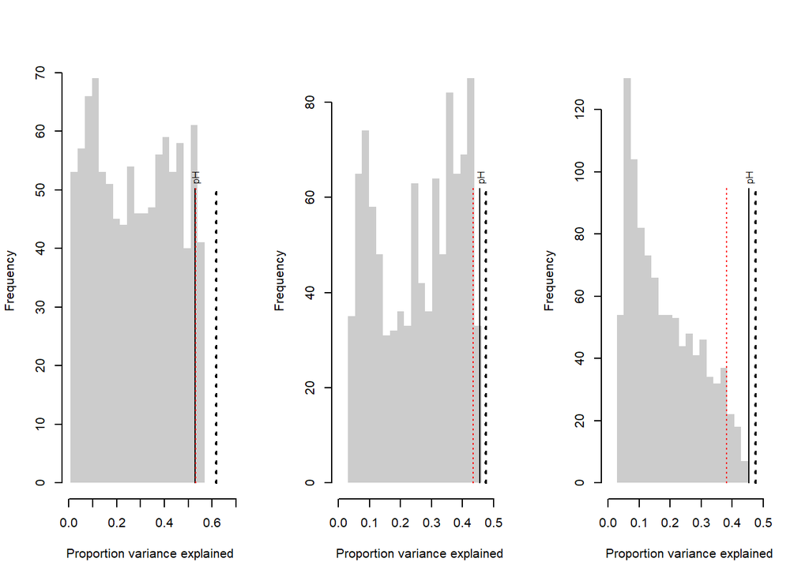

```r
data("SWAP")
data("RLGH")

model.wa <- rioja::WA(sqrt(SWAP$spec), SWAP$pH) # Fitting WA model
model.mat <- rioja::MAT(SWAP$spec, SWAP$pH) # Fitting MAT model
model.wapls <- rioja::WAPLS(sqrt(SWAP$spec), SWAP$pH, npls = 2)

ph.wapls <- predict(model.wapls, newdata = sqrt(RLGH$spec)) # Predicting pH using WAPLS
ph.mat <- predict(model.mat, newdata = RLGH$spec) # Predicting pH using MAT
ph.wa <- predict(model.wa, newdata = sqrt(RLGH$spec)) # Predicting pH using WA

mat.tf <- randomTF(spp = SWAP$spec, env = data.frame(pH = SWAP$pH), fos = RLGH$spec, n = 999, fun = MAT, col = 1)
wa.tf <- randomTF(spp = sqrt(SWAP$spec), env = data.frame(pH = SWAP$pH),fos = sqrt(RLGH$spec), n = 999, fun = WA, col = 1)
wapls.tf <- randomTF(spp = sqrt(SWAP$spec), env = data.frame(pH = SWAP$pH),fos = sqrt(RLGH$spec), n = 999, fun = WAPLS, col = 2)

par(mfrow = c(1, 3))
plot(mat.tf)
plot(wa.tf)
plot(wapls.tf)
```

#### Test WA and WAPLS based reconstructions using obs.cor

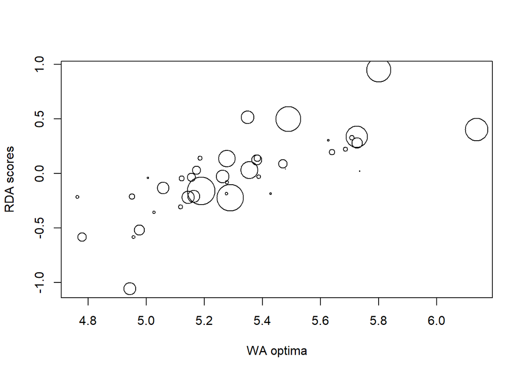

```r
wa.obs <- obs.cor(spp = sqrt(SWAP$spec), env = SWAP$pH, fos = sqrt(RLGH$spec), n = 999)
plot(wa.obs)
```

### 4. Exercise 1 in Kruschke

Table shows the x values evaluated using each model given

| Face | Model A | Model B | Model c |
| --- | --- | --- | --- |
| 1 | .25 | .1 | $\frac{12}{25}$ |
| 2 | .25 | .2 | $\frac{12}{50}$ |
| 3 | .25 | .3 | $\frac{12}{75}$ |
| 4 | .25 | .4 | $\frac{12}{100}$ |

- Model A shows no bias. Each possible value of the dice that can potentially be on the bottom after a role is given the probability of .25.
- Model B suggests bias towards larger values on the die. For instance, 4 is predicted to have a 40% chance that it will be the bottom face after any given roll. In contrast, 1 (the lowest value on the die) only has a 10% chance of being on the bottom of the die.
- Model C shows bias that is inverse to that of Model B, smaller values have a greater likelihood of being the bottom face.